# LASSO Regression on Cellphone Use Addiction

IDC6940 Capstone — Problematic Mobile Phone Use

Richard Odgers, Melissa Bolen, Jillian Mouser, Jonathan De La Torre (Advisor: Dr. Cohen)

2026-07-22

## Project Overview

Using LASSO Regression to Predict Cell Phone Addiction

Purpose

- Investigate factors associated with cell phone addiction.
- Identify the most important predictors of addiction.
- Use LASSO regression to reduce the number of variables while maintaining predictive accuracy.

Research Question

Which behavioral and demographic factors are the strongest predictors of cell phone addiction?

## Introduction and Literature Review

Background

- Smartphone use has increased dramatically worldwide.
- Excessive use has been linked to:
  - Anxiety
  - Depression
  - Poor sleep quality
  - Lower academic performance
  - Reduced productivity

## Introduction and Literature Review

Previous studies consistently show that:

- Younger individuals tend to have higher addiction scores.
- Mental health factors play an important role.
- Social media and entertainment apps are major contributors.
- Many studies rely on traditional regression methods.

Few studies use LASSO regression to determine which predictors truly matter most when many variables are considered simultaneously. (Busch and McCarthy 2021)

## What is LASSO?

LASSO Regression (Least Absolute Shrinkage and Selection Operator) is a machine learning technique that:

- Builds a prediction model
- Shrinks less important coefficients toward zero
- Removes unnecessary variables
- Produces a simpler, more interpretable model

## Why LASSO?

- Prevents overfitting
- Handles datasets with many predictors
- Improves model interpretability
- Selects only variables that contribute meaningful information

Simple Visualization:

Many Variables -> LASSO Penalty -> Only Important Variables Remain

## The Problem

There are many possible factors that may influence cell phone addiction:

- Age
- Gender
- Daily phone use
- Social media habits
- Sleep
- Mental health
- Academic performance
- Lifestyle factors

## The Problem

Smartphone use has shifted from convenience to dependency.

- Compulsive checking, withdrawal, daily-life interference
- Links to anxiety, sleep loss, and academic strain (Lin et al. 2014)
- Dozens of overlapping survey variables → multicollinearity (James et al. 2013)

Why This Project Matters

- Demonstrates an application of machine learning in behavioral research.
- Identifies the strongest predictors of cell phone addiction.
- Creates a model that is easier to interpret than traditional regression.
- Results may help guide future interventions and prevention efforts.

## Our Data

Survey data collected in **China** using a Computer Adaptive Testing (CAT) item bank (Gao et al. 2024) — **$n = 1{,}619$** complete cases

| Abbrev. | Scale |
| --- | --- |
| NMP | Nomophobia |
| SAPS | Smartphone addiction proneness |
| SPAI | Smartphone Addiction Inventory (outcome) |
| MPAS | Mobile Phone Addiction Scale |
| MPATS | Mobile Phone Addiction Tendency Scale |
| SAS | Smartphone Addiction Scale (SAS-C / SAS-CA) |

Plus age, gender, and grade (mean age $= 18.8$; 991 F / 628 M).

## Outcome & Approach

**Primary outcome:** SPAI total — sum of 20 SPAI items (20–80; mean $= 41.8$)

**Predictors:** NMP, SAPS, MPAS, MPATS, SAS items + demographics — SPAI items excluded (they define the score)

**Method:** LASSO (Tibshirani 1996) — $L_1$ penalty shrinks weak coefficients to zero (James et al. 2013; Hesterberg et al. 2008)

$$\min_{\boldsymbol{\beta}}
\left\{
\sum_{i=1}^{n}
\left(y_i - \beta_0 - \sum_{j=1}^{p}\beta_j x_{ij}\right)^2
+ \lambda \sum_{j=1}^{p}|\beta_j|
\right\}$$

## A Two-Phase Iterative Procedure

### Phase 1 — Select & Validate

- Fit LASSO at `lambda.min`; drop zero-coefficient predictors
- Refit the survivors at the **same** `lambda.min` confirming the first fit already removed the noise and lets coefficients re-adjust.

### Phase 2 — Escalating Search

- Switch to `lambda.1se`, which drops predictors more aggressively and refit
- Repeat: raise the penalty to a **larger multiple** of `lambda.1se`, refit, and check metrics with each next multiple chosen only *after* seeing the prior refit’s results

## Model Selection Rule

Every candidate fit across **both phases** is compared on test RMSE, MAE, R², and MAPE.

- The candidate with the strongest metrics overall leads
- When two or more candidates score nearly the same, the model with fewer predictors is preferred, since a simpler model that costs little to no measurable accuracy is the better choice
- From the best model we pick within each phase, we want to look at the top 5 predictors

## Model Evaluation Metrics

- **R²** — Proportion of test set variance in SPAI explained by model
- **RMSE** — Root Mean Squared Error: average magnitude of prediction errors
- **MAE** — Mean Absolute Error: average magnitude of errors between prediction and actual values
- **MAPE** — Mean Absolute Percentage Error: average magnitude of errors expressed as percentage
- **Normalized MAE** - Normalized Mean Absolute Error: MAE divided by a normalized factor
- **OVR** - Overall Variable Remaining: The amount of predictor variables left after shrinkage

## Tuning Criteria

How each refit was penalized

#### Penalty Selection

**`lambda.min`**

The λ with lowest cross-validated error. Maximizes predictive accuracy. Less aggressive about zeroing out coefficients.

**`lambda.1se`**

The largest λ within one standard error of the minimum CV error. Smaller amount of accuracy. Preferred model for shrinkage.

**Increasing multiples of `lambda.1se`**

Applied on later refits, each multiple chosen adaptively after reviewing the prior refit’s metrics.

## SPAI Severity in the Sample

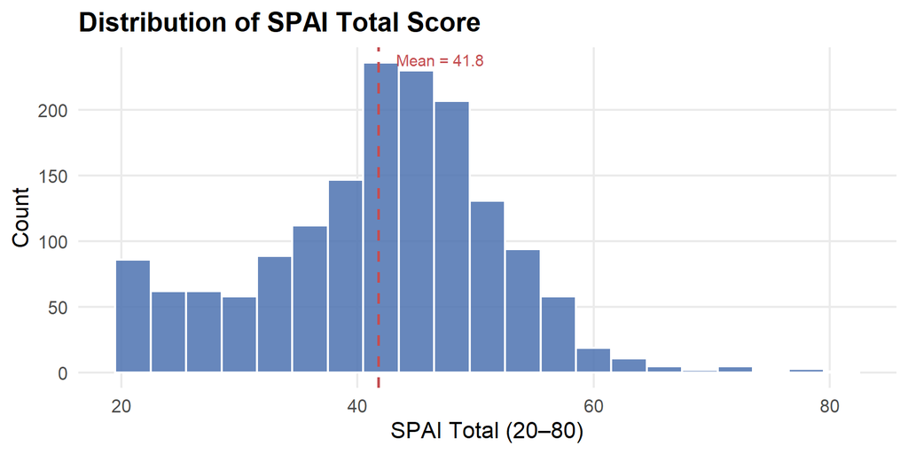

Figure 1

## Data Preprocessing

- $n = 1{,}619$ complete cases; no listwise missingness
- SPAI total = sum of 20 SPAI items; other SPAI items removed from predictors
- Model matrix from NMP, SAPS, MPAS, MPATS, SAS items + demographics
- 80/20 train–test split

## Model Fit: Actual vs. Predicted Total SPAI Score

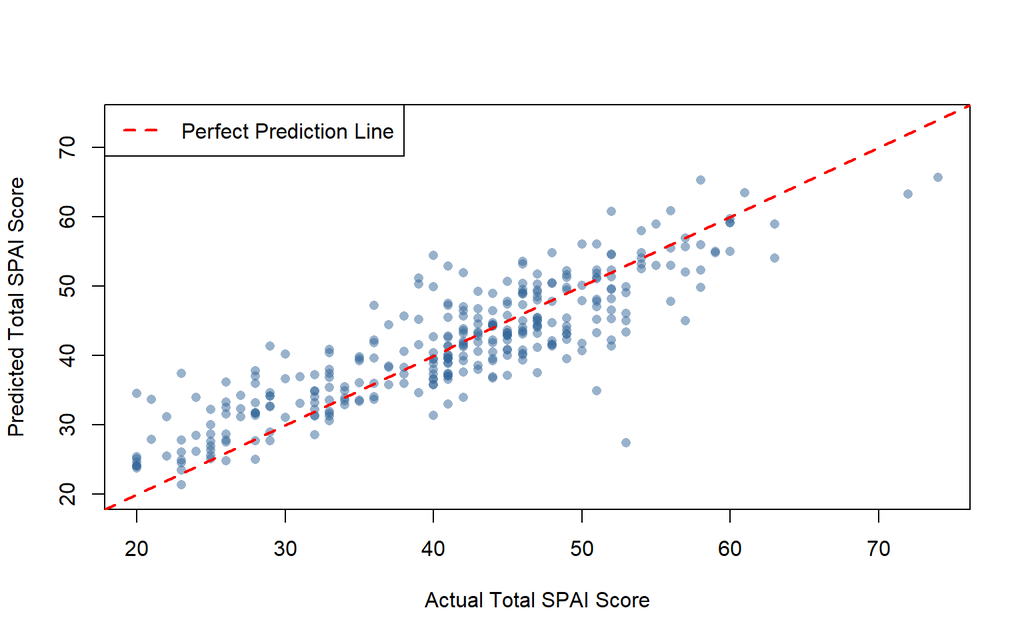

## Lasso Model Comparison Table

| Model | OVR | Test RMSE | Test MAE | Test R-Squared | Optimal Lambda |
| --- | --- | --- | --- | --- | --- |
| Baseline | 81 | 5.234 | 3.999 | 0.743 | NA |
| LASSO 1 | 52 | 5.170 | 3.971 | 0.749 | 0.074 |
| LASSO 2 | 52 | 5.214 | 3.990 | 0.745 | 0.020 |
| Lambda 1SE | 33 | 5.163 | 3.991 | 0.750 | 0.227 |
| Strict | 28 | 5.255 | 4.108 | 0.741 | 0.577 |
| Ultra | 22 | 5.528 | 4.108 | 0.713 | 1.195 |
| Terminal | 19 | 5.830 | 4.631 | 0.681 | 1.673 |

## Final Lasso Regression Model

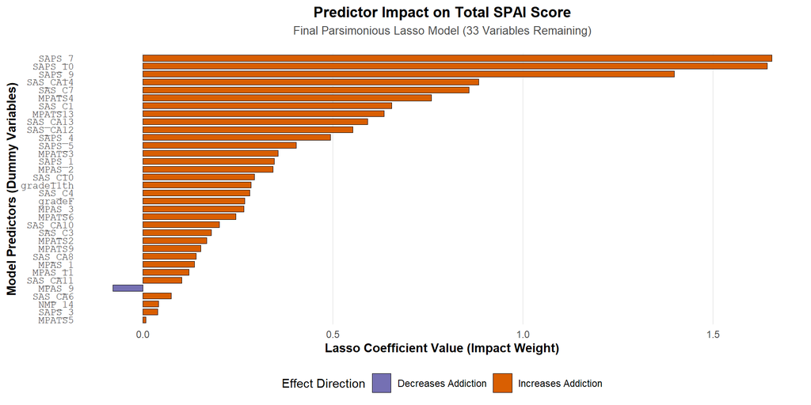

## Optimal Number of Predictor Variables

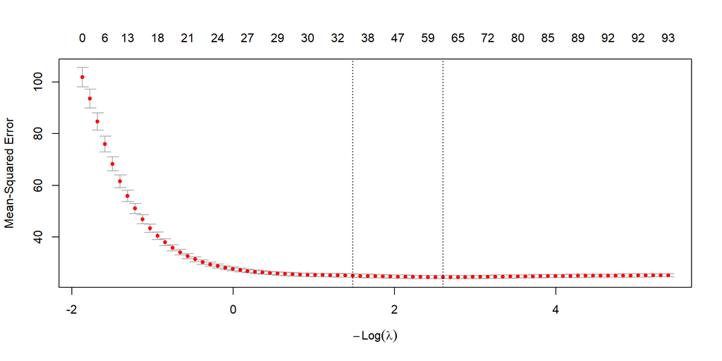

## Final Model Selection for Real Life Application

| Model | OVR | RMSE | MAE | R² | Norm MAE (%) | MAPE (%) |
| --- | --- | --- | --- | --- | --- | --- |
| Baseline | 81 | 5.234 | 3.999 | 0.743 | 7.41 | 10.59 |
| LASSO 1 | 52 | 5.170 | 3.971 | 0.749 | 7.35 | 10.58 |
| LASSO 2 | 52 | 5.214 | 3.990 | 0.745 | 7.39 | 10.60 |
| Lambda 1SE | 33 | 5.163 | 3.991 | 0.750 | 7.39 | 10.71 |
| Strict | 28 | 5.255 | 4.108 | 0.741 | 7.61 | 11.21 |
| Ultra | 22 | 5.528 | 4.108 | 0.713 | 8.06 | 12.14 |
| Terminal | 19 | 5.830 | 4.631 | 0.681 | 8.58 | 13.08 |
| Top 5 (33) | 5 | 6.020 | 4.711 | 0.660 | 8.72 | 12.65 |
| Top 5 (52/22) | 5 | 6.226 | 4.836 | 0.636 | 8.96 | 12.91 |

## Questions to ask

1. Even when I think I should stop using my mobile phone, I will continue to use it and cannot stop.
2. It has become a habit of me to spend a lot of time on my mobile phone.
3. I feel very panic when I can’t use my mobile phone.
4. I don’t get enough sleep and feel tired from using mobile phone too much.
5. Playing mobile phone has affected my academic performance.

## Conclusion

- Iterative LASSO on Chinese CAT bank (Gao et al. 2024): predict SPAI total from non-SPAI items + demographics
- 81 → 52 (`lambda.min`) → **33** (`lambda.1se`): best balance of test error and complexity
- Test RMSE $= 5.16$, test $R^2 = 0.75$ (~59% fewer predictors than baseline)
- Further shrinkage (28 / 22 / 19) degraded accuracy ($R^2 < 0.70$ at 19) → stopping rule
- **SAPS** and **SAS** dominate; smaller MPATS role; **NMP** largely zeroed out
- Post-LASSO OLS on five items: test $R^2 = 0.66$ (below 0.75, strong for five items)
- Those items: compulsive use, habitual time spent, separation panic, sleep loss, academic interference
- High $R^2$ = **convergent validity**, not causation (Gao et al. 2024; Lin et al. 2014; James et al. 2013)

## China & Generalizability

Sample collected in **China** among predominantly young adults (mean age $= 18.8$), more female than male (Gao et al. 2024)

- Multicollinearity ($r > 0.60$) motivates LASSO over OLS (McNeish 2015)
- Do not generalize without external validation
- 33-item LASSO—and, where brevity matters, the five-item OLS subset—can estimate SPAI-like severity pending prospective validation

## Future Work

- Robustness across train–test splits and random seeds
- Validate short-form item sets in independent samples
- Pursue group LASSO more systematically (scale groupings and penalties vs. iterative plain LASSO)
- Extend beyond the Chinese young-adult cohort to separate context-specific from universal predictors

## References

Busch, Peter André, and Stephen McCarthy. 2021. “Antecedents and Consequences of Problematic Smartphone Use: A Systematic Literature Review of an Emerging Research Area.” *Computers in Human Behavior* 114: 106414. https://doi.org/10.1016/j.chb.2020.106414.

Gao, Yaojie, Xiaorui Liu, Zhao Zhou, Miao Chao, and Tour Liu. 2024. “Data for Developing Computerized Adaptive Testing of Problematic Mobile Phone Use.” *Data in Brief* 55: 110746. https://doi.org/10.1016/j.dib.2024.110746.

Hesterberg, Tim, Nam H. Choi, Lukas Meier, and Chris Fraley. 2008. “Least Angle and $\ell_1$ Penalized Regression: A Review.” *Statistics Surveys* 2: 61–93. https://doi.org/10.1214/08-SS035.

James, Gareth, Daniela Witten, Trevor Hastie, and Robert Tibshirani. 2013. *An Introduction to Statistical Learning*. Springer. https://doi.org/10.1007/978-1-4614-7138-7.

Lin, Yu-Hsuan, Li-Ren Chang, Yun-Hsuan Lee, Hsiang-Wei Tseng, Terry B. J. Kuo, and Sheng-Hsuan Chen. 2014. “Development and Validation of the Smartphone Addiction Inventory (SPAI).” *PLoS ONE* 9 (6): e98312. https://doi.org/10.1371/journal.pone.0098312.

McNeish, Daniel M. 2015. “Using LASSO for Predictor Selection and to Assuage Overfitting: A Method Long Overlooked in Behavioral Sciences.” *Multivariate Behavioral Research* 50 (5): 471–84.

Tibshirani, Robert. 1996. “Regression Shrinkage and Selection via the Lasso.” *Journal of the Royal Statistical Society: Series B (Methodological)* 58 (1): 267–88.